# R Notebook

Results presented in “Soil fauna diversity and chemical stressors: a review of knowledge gaps and roadmap for future research”.

Figures are created from the script “FIGURES.R”.

## How many studies included?

```r
nrow(metadatreview)
```

```
## [1] 274
```

# 1. Mapping knowledge gaps

## 1.1. Geographical bias

Are there geographical bias and what regions are poorly covered ?

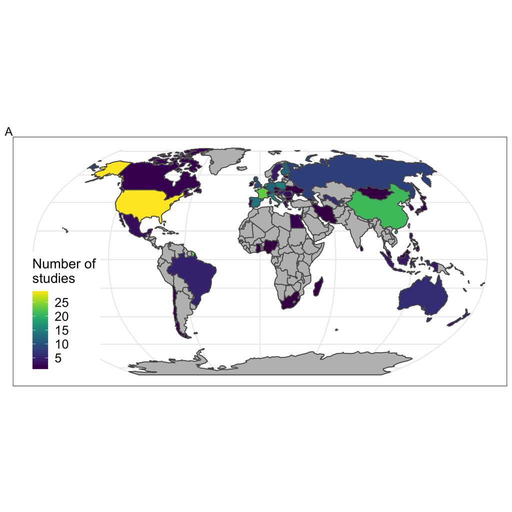

Distribution of studies included by country

Countries most represented?

```r
stud <- metadatreview %>%
  group_by(Country) %>%
  summarize(no.stu = n())
multicountrystud <- stud[grepl(";|,", stud$Country),]

# Manually add multiple countries studies:
addingcountries <- data.frame(rbind(c("Brazil", 1), c("Portugal", 1),
                                    c("Canada", 1), c("france", 1), c("The Netherlands", 1), c("Switzerland", 1),
                                    c("Germany", 1), c("The Netherlands", 1), c("UK", 1), c("Portugal", 1),
                                    c("Indonesia", 1),c("Malaysia", 1),
                                    c("UK", 1),
                                    c("The Netherlands", 1), c("Belgium", 1), c("france", 1), c("germany", 1)))
colnames(addingcountries) <- colnames(stud)
addingcountries$no.stu <- as.numeric(addingcountries$no.stu)

stud <- rbind(as.data.frame(stud), addingcountries)

# harmonize country names
stud <- stud %>%
  mutate(iso =  countrycode(stud$Country, origin = "country.name", destination = "iso3c")) %>%
  dplyr::group_by(iso) %>%
  summarize(no.stud = sum(no.stu, na.rm = TRUE))
stud[stud$no.stud > 20,]
```

| iso | no.stud |
| --- | --- |
| CHN | 21 |
| FRA | 23 |
| USA | 29 |

## 1.2. Pollutant types

### Time span of studies?

```r
summary(metadatreview$Published.Year)
```

```
##    Min. 1st Qu.  Median    Mean 3rd Qu.    Max.
##    1991    2003    2009    2008    2014    2018
```

### Pollutants most/least represented?

```r
whichPollutionType <- c("Metals", "PAH", "Pesticides", "Plastics/Plasticizers","Pharmaceuticals","Radiation", "Nanoparticles", "Others")

iterations  <-  length(whichPollutionType)
variables <-  1


output <- matrix(ncol=variables, nrow=iterations)

for(i in 1:iterations){
  output[i,] <- length(grep(whichPollutionType[i], ignore.case = TRUE, as.character(metadatreview$PollutantType)))
}

output <- data.frame(PollutionType = whichPollutionType,
                     no.studies = output)

kable(output)
```

| PollutionType | no.studies |
| --- | --- |
| Metals | 159 |
| PAH | 19 |
| Pesticides | 89 |
| Plastics/Plasticizers | 2 |
| Pharmaceuticals | 14 |
| Radiation | 3 |
| Nanoparticles | 2 |
| Others | 7 |

### Figure 2B - Time trends

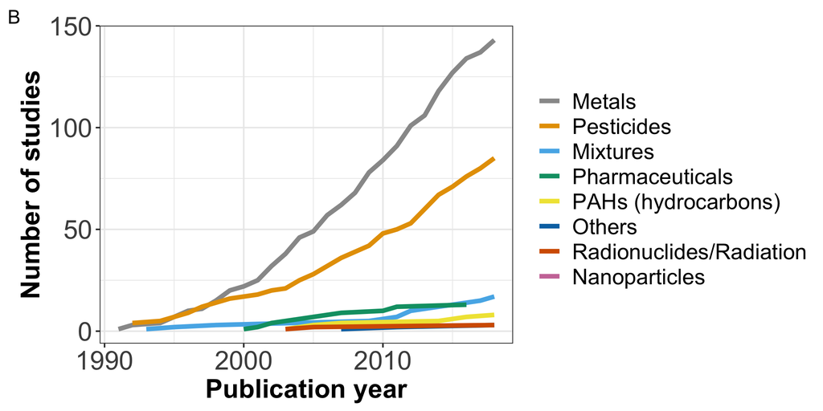

Cumulative number of studies on each type of pollutant studied through time

### What are the human activities responsible for soil pollution that are the most commonly studied ?

```r
whichPollutionSource <- c("Agricultural/livestock","Industrial","Mining/Smelting","Military/Wars",                        "Natural/geogenic","Waste/Sewage","Urban/Transport","Others")

iterations  <-  length(whichPollutionSource)
variables <-  1


output <- matrix(ncol=variables, nrow=iterations)

for(i in 1:iterations){
   output[i,] <- length(grep(whichPollutionSource[i], ignore.case = TRUE, as.character(metadatreview$PollutionSource)))
}

output <- data.frame(output)
output$PollutionSource <- whichPollutionSource

kable(output)
```

| output | PollutionSource |
| --- | --- |
| 100 | Agricultural/livestock |
| 31 | Industrial |
| 73 | Mining/Smelting |
| 9 | Military/Wars |
| 3 | Natural/geogenic |
| 23 | Waste/Sewage |
| 18 | Urban/Transport |
| 37 | Others |

```r
# sum up industrial/mining/waste (overlaps)
sum(output$output[output$PollutionSource=="Industrial"],
    output$output[output$PollutionSource=="Mining/Smelting"])
```

```
## [1] 104
```

```r
metadatreview$PollutantName[metadatreview$PollutantType=="Others"]
```

```
## [1] salt: chloride and sodium salt
## [3] chemical warfare agents
## 195 Levels:  ... Zn,Pb,Cd
```

### Mixture of chemicals: what scenarios studied?

```r
# create new pol type where = mixture when more than one category of pollutants are involved
metadatreview$PollutantType2 <- as.factor(ifelse(grepl(",", metadatreview$PollutantType), "Mixture",                                    as.character(metadatreview$PollutantType)))

summary(metadatreview$PollutantType2)
```

```
##                                 Metals                                Mixture
##                                    143                                     17
##                          Nanoparticles                                 Others
##                                      2                                      3
## PAH (Polycyclic aromatic hydrocarbons)                             Pesticides
##                                      8                                     85
##                        Pharmaceuticals                Radionuclides/Radiation
##                                     13                                      3
```

When accounting for mixture across AND within pollutant categories: most studies focus on multiple chemicals. Indeed, half of the studies are observational, and most contaminations and pollutions involve multiple chemicals in real-world scenarios.

```r
# create new pol type where = mixture when more than one category of pollutant is involved (for plot purposes)
metadatreview$PollutantType3 <-as.factor(ifelse(
  # mixtures across and within categoreis of stressors
  grepl(",|;|and|several|many|multiple|nanomaterials|metals|cides|carbons|PAHs|agents|residues", metadatreview$PollutantName)|
    grepl(",", metadatreview$PollutantType), "Mixtures",
  as.character(metadatreview$PollutantType)))

summary(metadatreview$PollutantType3)
```

```
##                                 Metals                               Mixtures
##                                     34                                    185
##                          Nanoparticles                                 Others
##                                      1                                      1
## PAH (Polycyclic aromatic hydrocarbons)                             Pesticides
##                                      3                                     40
##                        Pharmaceuticals                Radionuclides/Radiation
##                                      7                                      3
```

## 1.3. Taxonomic groups

### What are the taxa most represented by the studies?

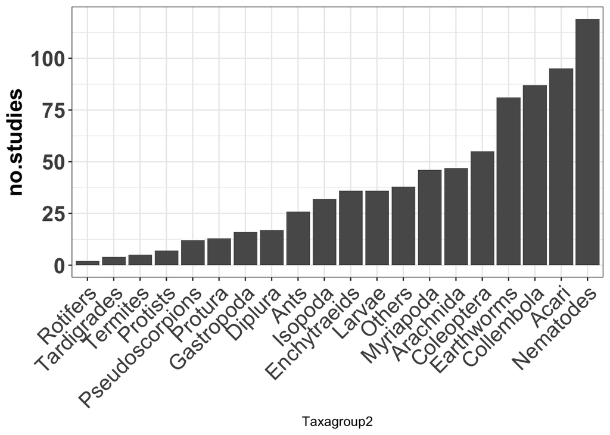

```r
whichTaxa <- c("Protists","Tardigrades","Rotifers","Nematodes","Enchytraeids","Acari","Collembola","Protura","Diplura","Pseudoscorpions","Ants","Termites","Isopoda","Myriapoda","Earthworms","Coleoptera","Arachnida","Gastropoda","Larvae","Others")

iterations = length(whichTaxa)
variables = 1

output <- matrix(ncol=variables, nrow=iterations)

for(i in 1:iterations){
  output[i,] <- length(grep(whichTaxa[i], ignore.case = TRUE, as.character(metadatreview$TaxaGroupAtlas)))
}

output <- data.frame(output)
output$Taxagroup <- whichTaxa
output$no.studies <- output$output
output$Taxagroup2 <- reorder(output$Taxagroup, output$output)


ggplot(output, aes(x = Taxagroup2, y = no.studies))+
  geom_col()+
   theme_bw() +
  theme(axis.text.y=element_text(face = "bold", size = rel(2)),
        axis.text.x=element_text(angle = 45, hjust = 1, size = rel(2)),
        axis.title.y = element_text(size=18, face = "bold"),

        #legend
        legend.title = element_blank() ,
        legend.text = element_text(size=16),
        legend.position = "bottom",

        #for the facets
        strip.text.x = element_text(size=16, face = "bold"),
        strip.background = element_rect(colour="black", fill="white"))
```

```r
kable(output[,1:2])
```

| output | Taxagroup |
| --- | --- |
| 7 | Protists |
| 4 | Tardigrades |
| 2 | Rotifers |
| 119 | Nematodes |
| 36 | Enchytraeids |
| 95 | Acari |
| 87 | Collembola |
| 13 | Protura |
| 17 | Diplura |
| 12 | Pseudoscorpions |
| 26 | Ants |
| 5 | Termites |
| 32 | Isopoda |
| 46 | Myriapoda |
| 81 | Earthworms |
| 55 | Coleoptera |
| 47 | Arachnida |
| 16 | Gastropoda |
| 36 | Larvae |
| 38 | Others |

### How many studies addressing macrofauna?

```r
metadatreview$Macrofaune <- factor(ifelse(grepl("Ants|Termites|Isopoda|Myriapoda|Earthworms|Coleoptera|Arachnida|Gastropoda",
                                  ignore.case = TRUE, as.character(metadatreview$TaxaGroupAtlas)), "Macrofauna", "Not macrofauna"))

summary(metadatreview$Macrofaune)
```

```
##     Macrofauna Not macrofauna
##            106            168
```

### Figure 2C - alluvial diagram

[figure not shown]

Alluvial diagram showing that a few emblematic taxonomic groups and pollutant types dominate research

# 2. Ecosystem perspective

What is the scope of studies on chemical stressors impacts on natural soil fauna communities?

## Figure 3- Scope of research

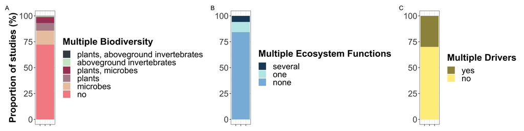

Studies addressing topics relevant to reach an ecosystem perspective

## 2.1. Multitrophic biodiversity and foodwebs

### How many soil fauna taxonomic groups per study?

```r
# count the no. of commas in the list
# subset dataframe keeping only paperID and drivers
df_taxo <- subset(metadatreview, select = c(X, TaxaGroupAtlas))

# split multiple taxa and pollutants into separate rows with strsplit
new_df_taxolist <- strsplit(as.character(df_taxo$TaxaGroupAtlas), ',')
new_df_combi_taxa <- data.frame(
  TaxaGroupAtlas = unlist(new_df_taxolist),
  PaperID = rep(df_taxo$X, sapply(new_df_taxolist, FUN = length)))

# no. of taxo group per paper
new_df_counts <- new_df_combi_taxa %>% group_by(PaperID) %>% summarise(no.taxa = n())

# descriptive stats
summary(new_df_counts)
```

```
##     PaperID          no.taxa
##  Min.   :  1.00   Min.   : 1.000
##  1st Qu.: 69.25   1st Qu.: 1.000
##  Median :137.50   Median : 1.000
##  Mean   :137.50   Mean   : 2.836
##  3rd Qu.:205.75   3rd Qu.: 3.000
##  Max.   :274.00   Max.   :14.000
```

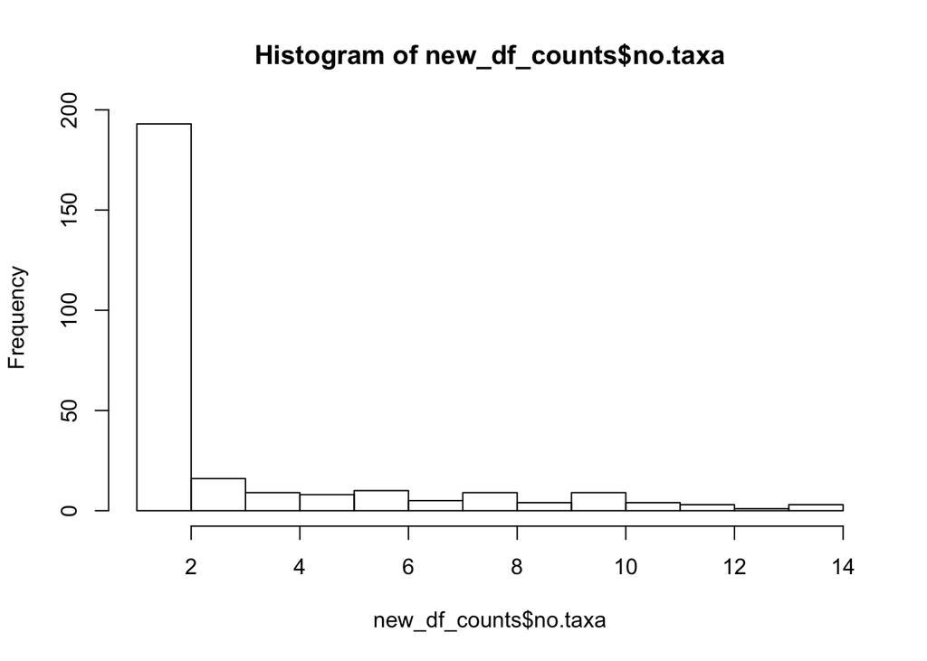

```r
hist(new_df_counts$no.taxa)
```

```r
table(new_df_counts$no.taxa)
```

```
##
##   1   2   3   4   5   6   7   8   9  10  11  12  13  14
## 161  32  16   9   8  10   5   9   4   9   4   3   1   3
```

```r
# Calculate the percentage of each group
new_df_counts <- new_df_counts %>%
  group_by(no.taxa) %>%
  summarise(no.studies = n(), Percent = n()/nrow(.) * 100)

kable(new_df_counts)
```

| no.taxa | no.studies | Percent |
| --- | --- | --- |
| 1 | 161 | 58.7591241 |
| 2 | 32 | 11.6788321 |
| 3 | 16 | 5.8394161 |
| 4 | 9 | 3.2846715 |
| 5 | 8 | 2.9197080 |
| 6 | 10 | 3.6496350 |
| 7 | 5 | 1.8248175 |
| 8 | 9 | 3.2846715 |
| 9 | 4 | 1.4598540 |
| 10 | 9 | 3.2846715 |
| 11 | 4 | 1.4598540 |
| 12 | 3 | 1.0948905 |
| 13 | 1 | 0.3649635 |
| 14 | 3 | 1.0948905 |

### Foodweb mentioned in the abstract?

```r
# number of papers with those keywords in the abstract
whichKeywords <- c("foodweb|food-web")


iterations = length(whichKeywords)
variables = 1

output <- matrix(ncol=variables, nrow=iterations)

for(i in 1:iterations){
  output[i,] <- length(grep(whichKeywords[i], ignore.case = TRUE, as.character(metadatreview$abstract)))
}

output <- data.frame(output)
output$Keyword <- whichKeywords
output
```

| output | Keyword |
| --- | --- |
| 4 | foodweb\|food-web |

```r
# number of papers with those keywords in the title
whichKeywords <- c("foodweb|food-web", "trophic")


iterations = length(whichKeywords)
variables = 1

output2 <- matrix(ncol=variables, nrow=iterations)

for(i in 1:iterations){
  output2[i,] <- length(grep(whichKeywords[i], ignore.case = TRUE, as.character(metadatreview$title)))
}

output2 <- data.frame(output2)
output2$Keyword <- whichKeywords
output2
```

| output2 | Keyword |
| --- | --- |
| 1 | foodweb\|food-web |
| 3 | trophic |

### What aspect of fauna diversity did the studies measured?

```r
whichDiv <- c("Abundance","Biomass","Richness","Shannon","Evenness", "Others")

iterations = length(whichDiv)
variables = 1

output <- matrix(ncol=variables, nrow=iterations)

for(i in 1:iterations){
  output[i,] <- length(grep(whichDiv[i], ignore.case = TRUE, as.character(metadatreview$DiversityMetric)))
}

output <- data.frame(output)
output$Measurement <- whichDiv

output
```

| output | Measurement |
| --- | --- |
| 253 | Abundance |
| 40 | Biomass |
| 124 | Richness |
| 97 | Shannon |
| 51 | Evenness |
| 55 | Others |

### Multitrophic-diversity: how often other groups were studied ?

```r
metadatreview <- metadatreview %>%
  mutate(OtherBiodiversity = factor(ifelse(OtherBiodiversity=="lichens", "plants", # lichens in the plant category for simplification
                                           as.character(OtherBiodiversity))))

# Calculate the percentage of each group
metadatreviewsummary <- metadatreview %>%
  group_by(OtherBiodiversity) %>%
  summarise(no.studies = n(), Percent = n()/nrow(.) * 100)

kable(metadatreviewsummary)
```

| OtherBiodiversity | no.studies | Percent |
| --- | --- | --- |
| aboveground invertebrates | 2 | 0.7299270 |
| microbes | 37 | 13.5036496 |
| no | 198 | 72.2627737 |
| plants | 20 | 7.2992701 |
| plants,aboveground invertebrates | 1 | 0.3649635 |
| plants,microbes | 16 | 5.8394161 |

## 2.2. Ecosystem functioning

### Proportion of studies addressing one or several functions?

```r
# Calculate the percentage of studies that have no,, one or several functions (based on full text screening)
metadatreviewsummary2 <- metadatreview %>%
  group_by(EcosystemFunction) %>%
  summarise(n(), Percent = n()/nrow(.) * 100)

kable(metadatreviewsummary2)
```

| EcosystemFunction | n() | Percent |
| --- | --- | --- |
| none | 231 | 84.306569 |
| one | 27 | 9.854015 |
| several | 16 | 5.839416 |

```r
# how many papers have function in the abstract?
subsetEF <- metadatreview[grepl("function", metadatreview$abstract),]
nrow(subsetEF)
```

```
## [1] 59
```

```r
# removing "functional groups" (nematodes studies often reported this)
nrow(subsetEF[!grepl("functional", subsetEF$abstract),])
```

```
## [1] 23
```

## 2.3. Multiple global drivers

### How often studies considered other drivers of global change?

```r
# create the multiple stressors var
metadatreview <- metadatreview %>%
  mutate(Multistressors = factor(ifelse(grepl(",", PollutantType), "Multiple stressors",
                                        "Single stressor")),
         Multidrivers = factor(ifelse(LandUse=="TRUE"|Intensification=="TRUE"|Fragmentation.Loss=="TRUE"|Nutrient=="TRUE"|ClimateChange=="TRUE"|Invasives=="TRUE", "yes", "no")))

# Calculate the percentage of each group
metadatreviewsummary3 <- metadatreview %>%
  group_by(Multidrivers) %>%
  summarise(no.studies = n(), Percent = n()/nrow(.) * 100)
```

### Drivers considered

```r
# create the list of vector each corresponding to a separate circle
multiGCDpapers <- data.frame(no.stu = t(
  data.frame(
    withLUI = nrow(metadatreview[metadatreview$Intensification == "TRUE", ]),
    withLUC = nrow(metadatreview[metadatreview$LandUse == "TRUE", ]),
    withInvas = nrow(metadatreview[metadatreview$Invasives == "TRUE", ]),
    withClim = nrow(metadatreview[metadatreview$ClimateChange == "TRUE", ]),
    withNut = nrow(metadatreview[metadatreview$Nutrient == "TRUE", ]),
    withFragm = nrow(metadatreview[metadatreview$Fragmentation.Loss == "TRUE", ])
  )
))

multiGCDpapers$OtherDrivers <- rownames(multiGCDpapers)

kable(multiGCDpapers)
```

|  | no.stu | OtherDrivers |
| --- | --- | --- |
| withLUI | 28 | withLUI |
| withLUC | 22 | withLUC |
| withInvas | 1 | withInvas |
| withClim | 5 | withClim |
| withNut | 37 | withNut |
| withFragm | 0 | withFragm |

## Study types - experimental or observational?

```r
summary(metadatreview$ExperimentObservation)
```

```
##                                          Experimental
##                          1                        133
## Experimental,Observational              Observational
##                          1                        139
```

## What types of ecosystems/land covers are represented?

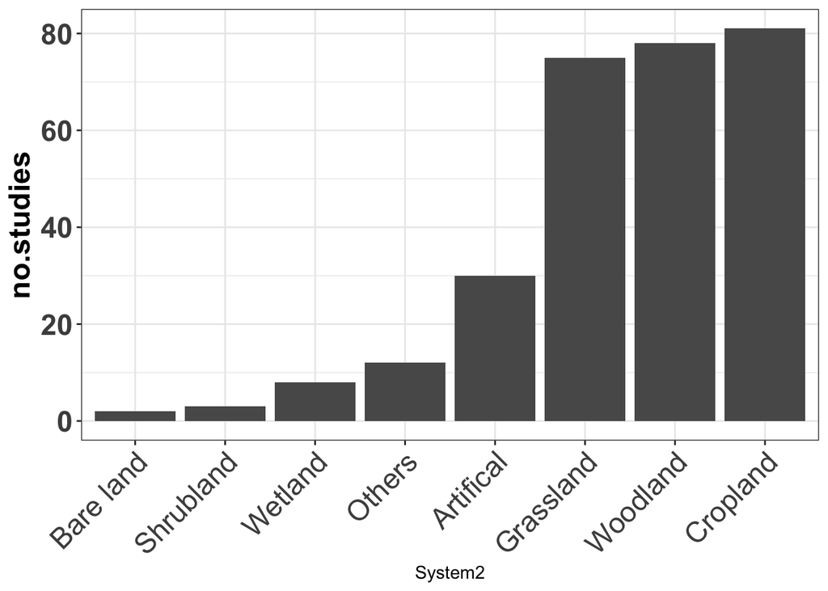

```r
whichSystem <- c("Grassland","Woodland","Cropland","Wetland","Artifical","Bare land","Shrubland","Others")

iterations = length(whichSystem)
variables = 1

output <- matrix(ncol=variables, nrow=iterations)

for(i in 1:iterations){
  output[i,] <- length(grep(whichSystem[i], ignore.case = TRUE, as.character(metadatreview$System)))
}

output <- data.frame(output)
output$System <- whichSystem
output$no.studies <- output$output
output$System2 <- reorder(output$System, output$output)



ggplot(output, aes(x = System2, y = no.studies))+
  geom_col()+
   theme_bw() +
  theme(axis.text.y=element_text(face = "bold", size = rel(2)),
        axis.text.x=element_text(angle = 45, hjust = 1, size = rel(2)),
        axis.title.y = element_text(size=18, face = "bold"),

        #legend
        legend.title = element_blank() ,
        legend.text = element_text(size=16),
        legend.position = "bottom",

        #for the facets
        strip.text.x = element_text(size=16, face = "bold"),
        strip.background = element_rect(colour="black", fill="white"))
```

### Bioindicators studies

```r
# # 22 studies have bioindicator in the abstract
whichKeywords <- c("bioindicator|bio-indicator")


iterations = length(whichKeywords)
variables = 1

output <- matrix(ncol=variables, nrow=iterations)

for(i in 1:iterations){
  output[i,] <- length(grep(whichKeywords[i], ignore.case = TRUE, as.character(metadatreview$abstract)))
}

output <- data.frame(output)
output$Keyword <- whichKeywords
output
```

| output | Keyword |
| --- | --- |
| 22 | bioindicator\|bio-indicator |

```r
# list those papers
BioIndicStudiesAbstract <- metadatreview[grepl("bioindicator", metadatreview$abstract),]
BioIndicStudiesTitle <- metadatreview[grepl("bioindicator", metadatreview$title),]
BioIndicStudiesTitle
```

|  | X | authors | Published.Year | journal | title | abstract | DOI | ExperimentObservation | Country | DiversityMetric | PollutantName | PollutantType | PollutionSource | TaxaGroupAtlas | System | OtherBiodiversity | EcosystemFunction | ClimateChange | Nutrient | LandUse | Intensification | Fragmentation.Loss | Invasives | PollutantType2 | PollutantType3 | Macrofaune | Multistressors | Multidrivers |
| --- | --- | --- | --- | --- | --- | --- | --- | --- | --- | --- | --- | --- | --- | --- | --- | --- | --- | --- | --- | --- | --- | --- | --- | --- | --- | --- | --- | --- |
| 56 | 56 | Salamun, P.; Renco, M.; Kucanova, E.; Brazova, T.; Papajova, I.; Miklisova, D.; Hanzelova, V. | 2012 | Ecotoxicology | Nematodes as bioindicators of soil degradation due to heavy metals | The effect of distance from a heavy metal pollution source on the soil nematode community was investigated on four sampling sites along an 4 km transect originating at the Kovohuty a.s. Krompachy (pol… | 10.1007/s10646-012-0988-y | Observational | Slovakia | abundance,richness,shannons,others | As,Cd,Cr,Cu,Ni,Pb,Zn | Metals | Mining/Smelting | Nematodes | Grassland | no | none | FALSE | FALSE | FALSE | FALSE | FALSE | FALSE | Metals | Mixtures | Not macrofauna | Single stressor | no |
| 63 | 63 | Santorufo, L.; Van Gestel, C. A. M.; Rocco, A.; Maisto, G. | 2012 | Environmental Pollution | Soil invertebrates as bioindicators of urban soil quality | This study aimed at relating the abundance and diversity of invertebrate communities of urban soils to chemical and physical soil characteristics and to identify the taxa most sensitive or tolerant to… | 10.1016/j.envpol.2011.09.042 | Observational | Italy | abundance,richness,shannons,evenness,others | Cu,Zn,Pb | Metals | Urban/transport | Nematodes,Enchytraeids,Acari,Collembola,Diplura,Pseudoscorpions,Ants,Isopoda,Myriapoda,Earthworms,Coleoptera,Arachnida (spiders and scorpions),Larvae,Others | Artifical land (e.g. yards, cemeteries, parkings, open dump sites) | no | none | FALSE | FALSE | FALSE | FALSE | FALSE | FALSE | Metals | Mixtures | Macrofauna | Single stressor | no |
| 78 | 78 | Wahl, J. J.; Theron, P. D.; Maboeta, M. S. | 2012 | Ecotoxicology and Environmental Safety | Soil mesofauna as bioindicators to assess environmental disturbance at a platinum mine in South Africa | South Africa is rich in mineral resources and is one of the leading raw material exporters in the world. Mining is essential for economic development, but also has detrimental environmental consequenc… | 10.1016/j.ecoenv.2012.09.027 | Observational | South Africa | abundance | Cu,Ni,Cr,Co | Metals | Mining/Smelting | Acari,Collembola | Artifical land (e.g. yards, cemeteries, parkings, open dump sites) | no | none | FALSE | FALSE | FALSE | FALSE | FALSE | FALSE | Metals | Mixtures | Not macrofauna | Single stressor | no |
| 138 | 138 | Cebron, A.; Cortet, J.; Criquet, S.; Biaz, A.; Calvert, V.; Caupert, C.; Pernin, C.; Leyval, C. | 2011 | Research in Microbiology | Biological functioning of PAH-polluted and thermal desorption-treated soils assessed by fauna and microbial bioindicators | A large number of soil bioindicators were used to assess biological diversity and activity in soil polluted with polycyclic aromatic hydrocarbons (PAHs) and the same soil after thermal desorption (TD)… | 10.1016/j.resmic.2011.02.011 | Experimental | France | abundance,richness | Cu, Pb, Zn, PAH | Metals,PAH (Polycyclic aromatic hydrocarbons) | Industrial | Protists,Nematodes,Acari,Collembola | Artifical land (e.g. yards, cemeteries, parkings, open dump sites) | microbes | several | FALSE | FALSE | FALSE | FALSE | FALSE | FALSE | Mixture | Mixtures | Not macrofauna | Multiple stressors | no |
| 162 | 162 | Paoletti, M. G.; Sommaggio, D.; Favretto, M. R.; Petruzzelli, G.; Pezzarossa, B.; Barbafieri, M. | 1998 | Applied Soil Ecology | Earthworms as useful bioindicators of agroecosystem sustainability in orchards and vineyards with different inputs | Earthworm communities were studied in 72 different agroecosystems including vineyards and three types of orchards: apple, peach and kiwi. Orchards had different agricultural inputs, in particular copp… | 10.1016/s0929-1393(98)00036-5 | Observational | Italy | abundance,biomass | Cu,Zn | Metals | Agricultural/livestock | Earthworms | Others | no | none | FALSE | FALSE | FALSE | TRUE | FALSE | FALSE | Metals | Mixtures | Macrofauna | Single stressor | yes |
| 176 | 176 | Fiera, C. | 2009 | Pesquisa Agropecuaria Brasileira | Biodiversity of Collembola in urban soils and their use as bioindicators for pollution | The objective of this work was to evaluate the effects of pollutants on the abundance and diversity of Collembola in urban soils. The research was carried out in three parks (Cismigiu, Izvor and Unire… | 10.1590/s0100-204x2009000800010 | Observational | Romania | abundance | Cd, Pb, Cu, Zn | Metals | Urban/transport | Collembola | Others | no | none | FALSE | FALSE | FALSE | FALSE | FALSE | FALSE | Metals | Mixtures | Not macrofauna | Single stressor | no |
| 257 | 257 | Li, Q.; Zhong, S.; Li, F. P.; Lou, Y. L.; Liang, W. J. | 2011 | International Journal of Environment and Pollution | Nematode community structure as bioindicator of soil heavy metal pollution along an urban-rural gradient in southern Shenyang, China | Effects of heavy metals caused by urbanisation on soil nematode communities were investigated along an urban suburban rural gradient in southern Shenyang, China. The numbers of total nematodes increas… |  | Observational | China | abundance,richness,shannons,others | Cd, Cu, Pb, Zn | Metals | Urban/transport | Nematodes | Others | no | none | FALSE | FALSE | TRUE | FALSE | FALSE | FALSE | Metals | Mixtures | Not macrofauna | Single stressor | yes |

## Supplement Tables

### Supplement Table: full list of references

```r
write.csv(metadatreview[,c("authors", "title", "Published.Year", "journal", "DOI", "abstract")], "Output/FullListRefs.csv")
```

### Supplement Table: all papers with multitrophic-diversity

The list of papers focusing on plants, microbes and soil fauna was used to investigate whether the studies addressed indirect effects of chemical stressors, and if they considered foodweb and/or network approaches.

```r
# create a table with all studies that have at least one EF
WhichVars <- c("authors", "Published.Year", "journal", "title", "DOI", "Country", "DiversityMetric", "PollutantName", "PollutantType", "PollutionSource", "TaxaGroupAtlas", "System", "OtherBiodiversity", "EcosystemFunction", "Multidrivers")

MBdata <- metadatreview[metadatreview$OtherBiodiversity != "no",WhichVars]


write.csv(MBdata, "Output/TablePapersWithMultiDiv.csv")
```

### Supplement Table: all papers with functions

The list of papers having at least one function was used to investigate what type of functions and ecosystem services were addressed in those studies.

```r
# create a table with all studies that have at least one EF
WhichVars <- c("authors", "Published.Year", "journal", "title", "DOI", "Country", "DiversityMetric", "PollutantName", "PollutantType", "PollutionSource", "TaxaGroupAtlas", "System", "OtherBiodiversity", "EcosystemFunction", "Multidrivers")

EFdata <- metadatreview[metadatreview$EcosystemFunction != "none",WhichVars]


write.csv(EFdata, "Output/TablePapersWithEF.csv")
```

### Supplement Table: all papers with multi-drivers

The list of papers having multiple global change drivers was used to investigate how often studies had a full factorial design enabling to address interactive effects.

```r
WhichVars <- c("authors", "Published.Year", "journal", "title", "DOI", "Country", "DiversityMetric", "PollutantName", "PollutantType", "PollutionSource", "TaxaGroupAtlas", "System", "OtherBiodiversity", "EcosystemFunction", "Multidrivers",
               "ClimateChange", "Nutrient", "LandUse",
               "Intensification", "Fragmentation.Loss", "Invasives")

MultiGCDdata <- metadatreview[metadatreview$Multidrivers != "no",WhichVars]


write.csv(MultiGCDdata, "Output/TablePapersWithMultiGCDs.csv")
```

# Response to Referees

## R2 C5

```r
# Sousa's group
(metadatreview[grepl("Sousa", metadatreview$authors),])
```

|  | X | authors | Published.Year | journal | title | abstract | DOI | ExperimentObservation | Country | DiversityMetric | PollutantName | PollutantType | PollutionSource | TaxaGroupAtlas | System | OtherBiodiversity | EcosystemFunction | ClimateChange | Nutrient | LandUse | Intensification | Fragmentation.Loss | Invasives | PollutantType2 | PollutantType3 | Macrofaune | Multistressors | Multidrivers |
| --- | --- | --- | --- | --- | --- | --- | --- | --- | --- | --- | --- | --- | --- | --- | --- | --- | --- | --- | --- | --- | --- | --- | --- | --- | --- | --- | --- | --- |
| 128 | 128 | Chelinho, S.; Domene, X.; Andres, P.; Natal-da-Luz, T.; Norte, C.; Rufino, C.; Lopes, I.; Cachada, A.; Espindola, E.; Ribeiro, R.; Duarte, A. C.; Sousa, J. P. | 2014 | Applied Soil Ecology | Soil microarthropod community testing: A new approach to increase the ecological relevance of effect data for pesticide risk assessment | In the present study, a new complementary approach combining the use of the natural soil microarthropod community and conventional test methods was used. The effects of soil contamination with the ins… | 10.1016/j.apsoil.2013.06.009 | Experimental | Brazil;Portugal | abundance,richness,others | insecticide: carbofuran | Pesticides | Agricultural/livestock | Acari,Collembola,Protura,Pseudoscorpions,Ants,Isopoda,Myriapoda,Coleoptera,Arachnida (spiders and scorpions),Larvae,Others | Cropland | no | none | FALSE | FALSE | FALSE | FALSE | FALSE | FALSE | Pesticides | Pesticides | Macrofauna | Single stressor | no |

```r
(metadatreview[grepl("Chelinho", metadatreview$authors),])
```

|  | X | authors | Published.Year | journal | title | abstract | DOI | ExperimentObservation | Country | DiversityMetric | PollutantName | PollutantType | PollutionSource | TaxaGroupAtlas | System | OtherBiodiversity | EcosystemFunction | ClimateChange | Nutrient | LandUse | Intensification | Fragmentation.Loss | Invasives | PollutantType2 | PollutantType3 | Macrofaune | Multistressors | Multidrivers |
| --- | --- | --- | --- | --- | --- | --- | --- | --- | --- | --- | --- | --- | --- | --- | --- | --- | --- | --- | --- | --- | --- | --- | --- | --- | --- | --- | --- | --- |
| 128 | 128 | Chelinho, S.; Domene, X.; Andres, P.; Natal-da-Luz, T.; Norte, C.; Rufino, C.; Lopes, I.; Cachada, A.; Espindola, E.; Ribeiro, R.; Duarte, A. C.; Sousa, J. P. | 2014 | Applied Soil Ecology | Soil microarthropod community testing: A new approach to increase the ecological relevance of effect data for pesticide risk assessment | In the present study, a new complementary approach combining the use of the natural soil microarthropod community and conventional test methods was used. The effects of soil contamination with the ins… | 10.1016/j.apsoil.2013.06.009 | Experimental | Brazil;Portugal | abundance,richness,others | insecticide: carbofuran | Pesticides | Agricultural/livestock | Acari,Collembola,Protura,Pseudoscorpions,Ants,Isopoda,Myriapoda,Coleoptera,Arachnida (spiders and scorpions),Larvae,Others | Cropland | no | none | FALSE | FALSE | FALSE | FALSE | FALSE | FALSE | Pesticides | Pesticides | Macrofauna | Single stressor | no |

```r
(metadatreview[grepl("Rombke", metadatreview$authors),])
```

|  | X | authors | Published.Year | journal | title | abstract | DOI | ExperimentObservation | Country | DiversityMetric | PollutantName | PollutantType | PollutionSource | TaxaGroupAtlas | System | OtherBiodiversity | EcosystemFunction | ClimateChange | Nutrient | LandUse | Intensification | Fragmentation.Loss | Invasives | PollutantType2 | PollutantType3 | Macrofaune | Multistressors | Multidrivers |
| --- | --- | --- | --- | --- | --- | --- | --- | --- | --- | --- | --- | --- | --- | --- | --- | --- | --- | --- | --- | --- | --- | --- | --- | --- | --- | --- | --- | --- |
| 3 | 3 | Moser, T.; Van Gestel, C. A. M.; Jones, S. E.; Koolhaas, J. E.; Rodrigues, J. M. L.; Rombke, J. | 2004 | Ecotoxicology | Ring-testing and field-validation of a Terrestrial Model Ecosystem (TME) - An instrument for testing potentially harmful substances: Effects of carbendazim on enchytraeids | The effects of the fungicide carbendazim ( applied in the formulation Derosal(R)) on enchytraeids were determined in Terrestrial Model Ecosystem (TME) tests and field-validation studies. TMEs consiste… | 10.1023/B:ECTX.0000012407.42358.3e | Experimental | Germany, The Netherlands, UK, Portugal | abundance,richness | carbendazim | Pesticides | Agricultural/livestock | Nematodes | Cropland | no | none | FALSE | FALSE | FALSE | FALSE | FALSE | FALSE | Pesticides | Pesticides | Not macrofauna | Single stressor | no |
| 46 | 46 | Scheffczyk, A.; Floate, K. D.; Blanckenhorn, W. U.; During, R. A.; Klockner, A.; Lahr, J.; Lumaret, J. P.; Salamon, J. A.; Tixier, T.; Wohde, M.; Rombke, J. | 2016 | Environmental Toxicology and Chemistry | Nontarget effects of ivermectin residues on earthworms and springtails dwelling beneath dung of treated cattle in four countries | The authorization of veterinary medicinal products requires that they be assessed for nontarget effects in the environment. Numerous field studies have assessed these effects on dung organisms. Howeve… | 10.1002/etc.3306 | Experimental | Canada;France;Netherlands;Switzerland | abundance,richness,others | ivremectin | Pharmaceuticals | Agricultural/livestock | Collembola,Earthworms | Grassland | no | none | FALSE | FALSE | FALSE | FALSE | FALSE | FALSE | Pharmaceuticals | Pharmaceuticals | Macrofauna | Single stressor | no |
| 69 | 69 | Rombke, J.; Coors, A.; Fernandez, A. A.; Forster, B.; Fernandez, C.; Jensen, J.; Lumaret, J. P.; Cots, M. A. P.; Liebig, M. | 2010 | Applied Soil Ecology | Effects of the parasiticide ivermectin on the structure and function of dung and soil invertebrate communities in the field (Madrid, Spain) | The effects of the parasiticide ivermectin on dung and soil fauna as well as dung decomposition were assessed in a field study conducted near Madrid (Spain). Groups of cattle were treated with an inje… | 10.1016/j.apsoil.2010.05.004 | Experimental | Spain | abundance | parasiticide: ivremectin | Pharmaceuticals | Agricultural/livestock | Acari,Collembola,Ants,Myriapoda,Coleoptera,Arachnida (spiders and scorpions),Larvae | Grassland | no | none | FALSE | FALSE | FALSE | FALSE | FALSE | FALSE | Pharmaceuticals | Pharmaceuticals | Macrofauna | Single stressor | no |
| 184 | 184 | Beck, L.; Rombke, J.; Ruf, A.; Prinzing, A.; Woas, S. | 2004 | European Journal of Soil Biology | Effects of diflubenzuron and Bacillus thuringiensis var. kurstaki toxin on soil invertebrates of a mixed deciduous forest in the Upper Rhine Valley, Germany | The effects of two insecticides, diflubenzuron (Dimilin(R) 25 WP) and Bacillus thuringiensis var. kurstaki (B.t.k.; Dipel ES(R)) on the soil fauna of a deciduous forest in the Upper Rhine Valley were … | 10.1016/j.ejsobi.2003.08.003 | Experimental | Germany | abundance | insecticides | Pesticides | Agricultural/livestock | Enchytraeids,Acari,Collembola,Earthworms | Woodland | no | none | FALSE | FALSE | FALSE | FALSE | FALSE | FALSE | Pesticides | Mixtures | Macrofauna | Single stressor | no |
| 218 | 218 | Forster, B.; Garcia, M.; Francimari, O.; Rombke, J. | 2006 | European Journal of Soil Biology | Effects of carbendazim and lambda-cyhalothrin on soil invertebrates and leaf litter decomposition in semi-field and field tests under tropical conditions (Amazonia, Brazil) | Effects of the fungicide carbendazim and of the insecticide lambda-cyhalothrin on soil invertebrates and litter decomposition under tropical conditions were assessed in ecotoxicological semi-field stu… | 10.1016/j.ejsobi.2006.07.011 | Experimental | Brazil | abundance,biomass | insecticide, fungicide | Pesticides | Agricultural/livestock | Isopoda,Myriapoda,Earthworms,Mesofauna | Cropland | no | one | FALSE | FALSE | FALSE | FALSE | FALSE | FALSE | Pesticides | Mixtures | Macrofauna | Single stressor | no |
| 219 | 219 | Forster, B.; Boxall, A.; Coors, A.; Jensen, J.; Liebig, M.; Pope, L.; Moser, T.; Rombke, J. | 2011 | Ecotoxicology | Fate and effects of ivermectin on soil invertebrates in terrestrial model ecosystems | The effect of ivermectin on soil organisms was assessed in Terrestrial Model Ecosystems (TMEs). Intact soil cores were extracted from a pasture in England and kept for up to 14 weeks in the laboratory… | 10.1007/s10646-010-0575-z | Experimental | England | abundance,biomass | ivremectin | Pharmaceuticals | Agricultural/livestock | Nematodes,Enchytraeids,Acari,Collembola,Earthworms | Grassland | microbes | one | FALSE | FALSE | FALSE | FALSE | FALSE | FALSE | Pharmaceuticals | Pharmaceuticals | Macrofauna | Single stressor | no |
| 270 | 270 | Koolhaas, J. E.; Van Gestel, C. A. M.; Rombke, J.; Soares, Amvm; Jones, S. E. | 2004 | Ecotoxicology | Ring-testing and field-validation of a Terrestrial Model Ecosystem (TME) - An instrument for testing potentially harmful substances: Effects of carbendazim on soil microarthropod communities | The effects of the fungicide carbendazim (applied in the formulation Derosal) on soil microarthropod communities was determined in three Terrestrial Model Ecosystem (TME) tests and a. eldvalidation st… | 10.1023/b:ectx.0000012406.93004.03 | Experimental | The Netherlands | abundance,shannons | carbendazim | Pesticides | Others | Acari,Collembola | Grassland | no | none | FALSE | FALSE | FALSE | FALSE | FALSE | FALSE | Pesticides | Pesticides | Not macrofauna | Single stressor | no |

```r
metadatreview[grepl("Faber", metadatreview$authors),]
```

|  | X | authors | Published.Year | journal | title | abstract | DOI | ExperimentObservation | Country | DiversityMetric | PollutantName | PollutantType | PollutionSource | TaxaGroupAtlas | System | OtherBiodiversity | EcosystemFunction | ClimateChange | Nutrient | LandUse | Intensification | Fragmentation.Loss | Invasives | PollutantType2 | PollutantType3 | Macrofaune | Multistressors | Multidrivers |
| --- | --- | --- | --- | --- | --- | --- | --- | --- | --- | --- | --- | --- | --- | --- | --- | --- | --- | --- | --- | --- | --- | --- | --- | --- | --- | --- | --- | --- |
| 100 | 100 | Zaller, J. G.; Cantelmo, C.; Dos Santos, G.; Muther, S.; Gruber, E.; Pallua, P.; Mandl, K.; Friedrich, B.; Hofstetter, I.; Schmuckenschlager, B.; Faber, F. | 2018 | Environmental Science and Pollution Research | Herbicides in vineyards reduce grapevine root mycorrhization and alter soil microorganisms and the nutrient composition in grapevine roots, leaves, xylem sap and grape juice | Herbicides are increasingly applied in vineyards worldwide. However, not much is known on potential side effects on soil organisms or on the nutrition of grapevines (Vitis vinifera). In an experimenta… | 10.1007/s11356-018-2422-3 | Experimental | Austria | abundance | herbicides: glyphosate,flazasulfuron,glufosinate | Pesticides | Agricultural/livestock | Earthworms | Cropland | plants,microbes | one | FALSE | FALSE | FALSE | FALSE | FALSE | FALSE | Pesticides | Mixtures | Macrofauna | Single stressor | no |

```r
metadatreview[grepl("Filser", metadatreview$authors),]
```

|  | X | authors | Published.Year | journal | title | abstract | DOI | ExperimentObservation | Country | DiversityMetric | PollutantName | PollutantType | PollutionSource | TaxaGroupAtlas | System | OtherBiodiversity | EcosystemFunction | ClimateChange | Nutrient | LandUse | Intensification | Fragmentation.Loss | Invasives | PollutantType2 | PollutantType3 | Macrofaune | Multistressors | Multidrivers |
| --- | --- | --- | --- | --- | --- | --- | --- | --- | --- | --- | --- | --- | --- | --- | --- | --- | --- | --- | --- | --- | --- | --- | --- | --- | --- | --- | --- | --- |
| 175 | 175 | Bockl, M.; Blay, K.; Fischer, K.; Mommertz, S.; Filser, J. | 1998 | Applied Soil Ecology | Colonisation of a copper-decontaminated soil by micro- and mesofauna | Leaching with aminoacid hydrolysate is a new method for the decontamination of soils polluted with heavy metals. After this treatment, the soil seems to provide ideal conditions for bacterial growth. … | 10.1016/s0929-1393(98)00110-3 | Experimental | Germany | biomass | fungicide:Cu | Pesticides | Agricultural/livestock | Protists,Nematodes | NA | microbes | none | FALSE | FALSE | FALSE | FALSE | FALSE | FALSE | Pesticides | Pesticides | Not macrofauna | Single stressor | no |

```r
metadatreview[grepl("Gestel", metadatreview$authors),]
```

|  | X | authors | Published.Year | journal | title | abstract | DOI | ExperimentObservation | Country | DiversityMetric | PollutantName | PollutantType | PollutionSource | TaxaGroupAtlas | System | OtherBiodiversity | EcosystemFunction | ClimateChange | Nutrient | LandUse | Intensification | Fragmentation.Loss | Invasives | PollutantType2 | PollutantType3 | Macrofaune | Multistressors | Multidrivers |
| --- | --- | --- | --- | --- | --- | --- | --- | --- | --- | --- | --- | --- | --- | --- | --- | --- | --- | --- | --- | --- | --- | --- | --- | --- | --- | --- | --- | --- |
| 3 | 3 | Moser, T.; Van Gestel, C. A. M.; Jones, S. E.; Koolhaas, J. E.; Rodrigues, J. M. L.; Rombke, J. | 2004 | Ecotoxicology | Ring-testing and field-validation of a Terrestrial Model Ecosystem (TME) - An instrument for testing potentially harmful substances: Effects of carbendazim on enchytraeids | The effects of the fungicide carbendazim ( applied in the formulation Derosal(R)) on enchytraeids were determined in Terrestrial Model Ecosystem (TME) tests and field-validation studies. TMEs consiste… | 10.1023/B:ECTX.0000012407.42358.3e | Experimental | Germany, The Netherlands, UK, Portugal | abundance,richness | carbendazim | Pesticides | Agricultural/livestock | Nematodes | Cropland | no | none | FALSE | FALSE | FALSE | FALSE | FALSE | FALSE | Pesticides | Pesticides | Not macrofauna | Single stressor | no |
| 63 | 63 | Santorufo, L.; Van Gestel, C. A. M.; Rocco, A.; Maisto, G. | 2012 | Environmental Pollution | Soil invertebrates as bioindicators of urban soil quality | This study aimed at relating the abundance and diversity of invertebrate communities of urban soils to chemical and physical soil characteristics and to identify the taxa most sensitive or tolerant to… | 10.1016/j.envpol.2011.09.042 | Observational | Italy | abundance,richness,shannons,evenness,others | Cu,Zn,Pb | Metals | Urban/transport | Nematodes,Enchytraeids,Acari,Collembola,Diplura,Pseudoscorpions,Ants,Isopoda,Myriapoda,Earthworms,Coleoptera,Arachnida (spiders and scorpions),Larvae,Others | Artifical land (e.g. yards, cemeteries, parkings, open dump sites) | no | none | FALSE | FALSE | FALSE | FALSE | FALSE | FALSE | Metals | Mixtures | Macrofauna | Single stressor | no |
| 64 | 64 | Santorufo, L.; Van Gestel, C. A. M.; Maisto, G. | 2014 | Geoderma | Sampling season affects conclusions on soil arthropod community structure responses to metal pollution in Mediterranean urban soils | This study aimed to assess if the period of sampling affected conclusions on the responses of arthropod community structure to metal pollution in urban soils in the Mediterranean area. Higher temperat… | 10.1016/j.geoderma.2014.02.001 | Observational | Italy | abundance,richness,shannons,evenness,others | Cu,Zn,Pb | Metals | Urban/transport | Nematodes,Enchytraeids,Acari,Collembola,Diplura,Pseudoscorpions,Ants,Isopoda,Myriapoda,Earthworms,Coleoptera,Arachnida (spiders and scorpions),Larvae,Others | Artifical land (e.g. yards, cemeteries, parkings, open dump sites) | no | none | FALSE | FALSE | FALSE | FALSE | FALSE | FALSE | Metals | Mixtures | Macrofauna | Single stressor | no |
| 77 | 77 | van Gestel, C. A. M.; Koolhaas, J. E.; Hamers, T.; van Hoppe, M.; van Roovert, M.; Korsman, C.; Reineckec, S. A. | 2009 | Environmental Pollution | Effects of metal pollution on earthworm communities in a contaminated floodplain area: Linking biomarker, community and functional responses | Effects on earthworms in the contaminated floodplain area the Biesbosch, the Netherlands, were determined at different levels of organization using a combination of field and laboratory tests. The spe… | 10.1016/j.envpol.2008.11.002 | Observational | The Netherlands | abundance,biomass | Zn,Cu,Cd,PCB,PAH | Metals,PAH (Polycyclic aromatic hydrocarbons) | Others | Earthworms | Wetlands | no | one | FALSE | FALSE | FALSE | FALSE | FALSE | FALSE | Mixture | Mixtures | Macrofauna | Multiple stressors | no |
| 180 | 180 | Bleeker, E. A. J.; van Gestel, C. A. M. | 2007 | Environmental Pollution | Effects of spatial and temporal variation in metal availability on earthworms in floodplain soils of the river Dommel, The Netherlands | Regarding impact on ecological soil functioning, metal pollution is often considered a constant factor for certain sampling sites. However, especially bioavailable concentrations may differ in space a… | 10.1016/j.envpol.2007.01.034 | Observational | The Netherlands | biomass | Zn | Metals | Mining/Smelting | Earthworms | Wetlands | no | none | FALSE | FALSE | FALSE | FALSE | FALSE | FALSE | Metals | Metals | Macrofauna | Single stressor | no |
| 191 | 191 | De Silva, Rmcs; Asoka, P.; van Straalen, N. M.; van Gestel, C. A. M. | 2010 | Environmental Pollution | Chlorpyrifos causes decreased organic matter decomposition by suppressing earthworm and termite communities in tropical soil | Effects of pesticides on structural and functional properties of ecosystems are rarely studied under tropical conditions. In this study litterbag and earthworm field tests were performed simultaneousl… | 10.1016/j.envpol.2010.06.032 | Experimental | Sri Lanka | abundance,biomass | chlorpyrifos | Pesticides | Agricultural/livestock | Termites,Earthworms | Cropland | no | one | FALSE | FALSE | FALSE | FALSE | FALSE | FALSE | Pesticides | Pesticides | Macrofauna | Single stressor | no |
| 238 | 238 | Hobbelen, P. H. F.; van den Brink, P. J.; Hobbelen, J. F.; van Gestel, C. A. M. | 2006 | Soil Biology & Biochemistry | Effects of heavy metals on the structure and functioning of detritivore communities in a contaminated floodplain area | The aim of this study was to determine the effects of heavy metal pollution on the structure and functioning of detritivore soil communities that consist of isopods, millipedes and earthworms, in 15 h… | 10.1016/j.soilbio.2005.11.010 | Observational | The Netherlands | abundance,richness | Cd, Cu, Pb, Zn | Metals | Others | Isopoda,Myriapoda,Earthworms | Wetlands | no | one | FALSE | FALSE | FALSE | FALSE | FALSE | FALSE | Metals | Mixtures | Macrofauna | Single stressor | no |
| 268 | 268 | Kools, S. A. E.; Boivin, M. E. Y.; Van Der Wurff, A. W. G.; Berg, M. P.; Van Gestel, C. A. M.; Van Straalen, N. M. | 2009 | Ecotoxicology and Environmental Safety | Assessment of structure and function in metal polluted grasslands using Terrestrial Model Ecosystems | Ecosystem effects of metal pollution in field situations are hard to predict, since metals occur often in mixtures and links between structural (organisms) and functional endpoints (ecosystem processe… | 10.1016/j.ecoenv.2008.03.016 | Experimental | The Netherlands | abundance,biomass,shannons | Zn | Metals | Waste/sewage | Nematodes,Enchytraeids,Earthworms | Grassland | microbes | several | FALSE | FALSE | FALSE | FALSE | FALSE | FALSE | Metals | Metals | Macrofauna | Single stressor | no |
| 269 | 269 | Kools, S. A. E.; Berg, M. P.; Boivin, M. E. Y.; Kuenen, F. J. A.; van der Wurff, A. W. G.; van Gestel, C. A. M.; van Straalen, N. M. | 2008 | Science of the Total Environment | Stress responses investigated; application of zinc and heat to Terrestrial Model Ecosystems from heavy metal polluted grassland | This study tested the hypothesis that soils with a deprived biodiversity due to metal pollution are less stable than non-polluted soils, containing a more diverse community. For this, soils were sampl… | 10.1016/j.scitotenv.2008.06.057 | Experimental | The Netherlands | biomass | Zn | Metals | Others | Enchytraeids,Earthworms | Grassland | microbes | several | TRUE | FALSE | FALSE | FALSE | FALSE | FALSE | Metals | Metals | Macrofauna | Single stressor | yes |
| 270 | 270 | Koolhaas, J. E.; Van Gestel, C. A. M.; Rombke, J.; Soares, Amvm; Jones, S. E. | 2004 | Ecotoxicology | Ring-testing and field-validation of a Terrestrial Model Ecosystem (TME) - An instrument for testing potentially harmful substances: Effects of carbendazim on soil microarthropod communities | The effects of the fungicide carbendazim (applied in the formulation Derosal) on soil microarthropod communities was determined in three Terrestrial Model Ecosystem (TME) tests and a. eldvalidation st… | 10.1023/b:ectx.0000012406.93004.03 | Experimental | The Netherlands | abundance,shannons | carbendazim | Pesticides | Others | Acari,Collembola | Grassland | no | none | FALSE | FALSE | FALSE | FALSE | FALSE | FALSE | Pesticides | Pesticides | Not macrofauna | Single stressor | no |

```r
metadatreview[grepl("Reineck", metadatreview$authors),]
```

|  | X | authors | Published.Year | journal | title | abstract | DOI | ExperimentObservation | Country | DiversityMetric | PollutantName | PollutantType | PollutionSource | TaxaGroupAtlas | System | OtherBiodiversity | EcosystemFunction | ClimateChange | Nutrient | LandUse | Intensification | Fragmentation.Loss | Invasives | PollutantType2 | PollutantType3 | Macrofaune | Multistressors | Multidrivers |
| --- | --- | --- | --- | --- | --- | --- | --- | --- | --- | --- | --- | --- | --- | --- | --- | --- | --- | --- | --- | --- | --- | --- | --- | --- | --- | --- | --- | --- |
| 77 | 77 | van Gestel, C. A. M.; Koolhaas, J. E.; Hamers, T.; van Hoppe, M.; van Roovert, M.; Korsman, C.; Reineckec, S. A. | 2009 | Environmental Pollution | Effects of metal pollution on earthworm communities in a contaminated floodplain area: Linking biomarker, community and functional responses | Effects on earthworms in the contaminated floodplain area the Biesbosch, the Netherlands, were determined at different levels of organization using a combination of field and laboratory tests. The spe… | 10.1016/j.envpol.2008.11.002 | Observational | The Netherlands | abundance,biomass | Zn,Cu,Cd,PCB,PAH | Metals,PAH (Polycyclic aromatic hydrocarbons) | Others | Earthworms | Wetlands | no | one | FALSE | FALSE | FALSE | FALSE | FALSE | FALSE | Mixture | Mixtures | Macrofauna | Multiple stressors | no |

```r
metadatreview[grepl("Amorim", metadatreview$authors),]
```

| X | authors | Published.Year | journal | title | abstract | DOI | ExperimentObservation | Country | DiversityMetric | PollutantName | PollutantType | PollutionSource | TaxaGroupAtlas | System | OtherBiodiversity | EcosystemFunction | ClimateChange | Nutrient | LandUse | Intensification | Fragmentation.Loss | Invasives | PollutantType2 | PollutantType3 | Macrofaune | Multistressors | Multidrivers |
| --- | --- | --- | --- | --- | --- | --- | --- | --- | --- | --- | --- | --- | --- | --- | --- | --- | --- | --- | --- | --- | --- | --- | --- | --- | --- | --- | --- |

```r
metadatreview[grepl("Spurgeon", metadatreview$authors),]
```

|  | X | authors | Published.Year | journal | title | abstract | DOI | ExperimentObservation | Country | DiversityMetric | PollutantName | PollutantType | PollutionSource | TaxaGroupAtlas | System | OtherBiodiversity | EcosystemFunction | ClimateChange | Nutrient | LandUse | Intensification | Fragmentation.Loss | Invasives | PollutantType2 | PollutantType3 | Macrofaune | Multistressors | Multidrivers |
| --- | --- | --- | --- | --- | --- | --- | --- | --- | --- | --- | --- | --- | --- | --- | --- | --- | --- | --- | --- | --- | --- | --- | --- | --- | --- | --- | --- | --- |
| 91 | 91 | Spurgeon, D. J.; Hopkin, S. P. | 1999 | Journal of Applied Ecology | Seasonal variation in the abundance, biomass and biodiversity of earthworms in soils contaminated with metal emissions from a primary smelting works | 1. Earthworms (Annelida: Oligochaeta) were sampled on four occasions (spring, summer, autumn and winter) at 14 sites along two transects from a primary lead/zinc/cadmium smelting works at Avonmouth, U… | 10.1046/j.1365-2664.1999.00389.x | Observational | UK | abundance,shannons,others | Cd,Cu,Pb,Zn | Metals | Mining/Smelting | Earthworms | Grassland | no | none | FALSE | FALSE | FALSE | FALSE | FALSE | FALSE | Metals | Mixtures | Macrofauna | Single stressor | no |
| 94 | 94 | Spurgeon, D. J.; Hopkin, S. P. | 1996 | Applied Soil Ecology | The effects of metal contamination on earthworm populations around a smelting works: Quantifying species effects | The effects of metal contaminants on the population density and species composition of earthworms were studied at 22 sites around a primary smelting works situated at Avonmouth, southwest England. All… | 10.1016/0929-1393(96)00109-6 | Observational | UK | abundance | Cd, Cu, Pb, Zn, acid deposition | Metals | Industrial,Mining/Smelting | Earthworms | Grassland | no | none | FALSE | FALSE | FALSE | FALSE | FALSE | FALSE | Metals | Mixtures | Macrofauna | Single stressor | no |

```r
metadatreview[grepl("Hopkin", metadatreview$authors),]
```

|  | X | authors | Published.Year | journal | title | abstract | DOI | ExperimentObservation | Country | DiversityMetric | PollutantName | PollutantType | PollutionSource | TaxaGroupAtlas | System | OtherBiodiversity | EcosystemFunction | ClimateChange | Nutrient | LandUse | Intensification | Fragmentation.Loss | Invasives | PollutantType2 | PollutantType3 | Macrofaune | Multistressors | Multidrivers |
| --- | --- | --- | --- | --- | --- | --- | --- | --- | --- | --- | --- | --- | --- | --- | --- | --- | --- | --- | --- | --- | --- | --- | --- | --- | --- | --- | --- | --- |
| 91 | 91 | Spurgeon, D. J.; Hopkin, S. P. | 1999 | Journal of Applied Ecology | Seasonal variation in the abundance, biomass and biodiversity of earthworms in soils contaminated with metal emissions from a primary smelting works | 1. Earthworms (Annelida: Oligochaeta) were sampled on four occasions (spring, summer, autumn and winter) at 14 sites along two transects from a primary lead/zinc/cadmium smelting works at Avonmouth, U… | 10.1046/j.1365-2664.1999.00389.x | Observational | UK | abundance,shannons,others | Cd,Cu,Pb,Zn | Metals | Mining/Smelting | Earthworms | Grassland | no | none | FALSE | FALSE | FALSE | FALSE | FALSE | FALSE | Metals | Mixtures | Macrofauna | Single stressor | no |
| 94 | 94 | Spurgeon, D. J.; Hopkin, S. P. | 1996 | Applied Soil Ecology | The effects of metal contamination on earthworm populations around a smelting works: Quantifying species effects | The effects of metal contaminants on the population density and species composition of earthworms were studied at 22 sites around a primary smelting works situated at Avonmouth, southwest England. All… | 10.1016/0929-1393(96)00109-6 | Observational | UK | abundance | Cd, Cu, Pb, Zn, acid deposition | Metals | Industrial,Mining/Smelting | Earthworms | Grassland | no | none | FALSE | FALSE | FALSE | FALSE | FALSE | FALSE | Metals | Mixtures | Macrofauna | Single stressor | no |
| 140 | 140 | Fountain, M. T.; Hopkin, S. P. | 2004 | Ecotoxicology | A comparative study of the effects of metal contamination on collembola in the field and in the laboratory | We examined the species diversity and abundance of Collembola at 32 sampling points along a gradient of metal contamination in a rough grassland site ( Wolverhampton, England), formerly used for the d… | 10.1023/B:ECTX.0000037194.66321.2c | Observational | UK | abundance,richness,shannons,evenness,others | Cd, Cu, Pb, Zn | Metals | Mining/Smelting | Collembola | Woodland,Grassland,Artifical land (e.g. yards, cemeteries, parkings, open dump sites) | no | none | FALSE | FALSE | TRUE | FALSE | FALSE | FALSE | Metals | Mixtures | Not macrofauna | Single stressor | yes |
| 217 | 217 | Fountain, M. T.; Hopkin, S. P. | 2004 | Ecotoxicology | Biodiversity of Collembola in urban soils and the use of Folsomia candida to assess soil 'quality' | The effects of metal contamination on natural populations of Collembola in soils from five sites in the Wolverhampton area ( West Midlands, England) were examined. Analysis revealed that metal concent… | 10.1023/b:ectx.0000037192.70167.00 | Observational | UK | abundance,richness,shannons,evenness,others | Cd, Cu, Pb, Zn | Metals | Mining/Smelting,Urban/transport | Collembola | Woodland,Grassland | no | none | FALSE | FALSE | FALSE | FALSE | FALSE | FALSE | Metals | Mixtures | Not macrofauna | Single stressor | no |

```r
nrow(metadatreview[grepl("Koolhaas", metadatreview$authors),])
```

```
## [1] 3
```

```r
nrow(metadatreview[grepl("Holmstrup", metadatreview$authors),])
```

```
## [1] 5
```

```r
nrow(metadatreview[grepl("Posthuma", metadatreview$authors),])
```

```
## [1] 1
```

```r
nrow(metadatreview[grepl("Hedde", metadatreview$authors),])
```

```
## [1] 4
```

```r
nrow(metadatreview[grepl("Hobbelen", metadatreview$authors),])
```

```
## [1] 1
```

```r
nrow(metadatreview[grepl("Nahmani", metadatreview$authors),])
```

```
## [1] 3
```

```r
(metadatreview[grepl("Lavelle", metadatreview$authors),])
```

|  | X | authors | Published.Year | journal | title | abstract | DOI | ExperimentObservation | Country | DiversityMetric | PollutantName | PollutantType | PollutionSource | TaxaGroupAtlas | System | OtherBiodiversity | EcosystemFunction | ClimateChange | Nutrient | LandUse | Intensification | Fragmentation.Loss | Invasives | PollutantType2 | PollutantType3 | Macrofaune | Multistressors | Multidrivers |
| --- | --- | --- | --- | --- | --- | --- | --- | --- | --- | --- | --- | --- | --- | --- | --- | --- | --- | --- | --- | --- | --- | --- | --- | --- | --- | --- | --- | --- |
| 8 | 8 | Nahmani, J.; Lavelle, P.; Lapied, E.; van Oort, F. | 2003 | Pedobiologia | Effects of heavy metal soil pollution on earthworm communities in the north of France | In the alluvial plain of Scarpe-Escault, in northern France, past emissions from a Zn smelter resulted in a notable Zn, Cd, and Pb-contamination of soils. The aim of this study was to assess the respo… | 10.1078/0031-4056-00243 | Observational | France | abundance,richness | Cd, Pb, Zn | Metals | Mining/Smelting | Earthworms | Cropland,Woodland,Grassland | no | none | FALSE | FALSE | FALSE | FALSE | FALSE | FALSE | Metals | Mixtures | Macrofauna | Single stressor | no |
| 9 | 9 | Nahmani, J.; Lavelle, P. | 2002 | European Journal of Soil Biology | Effects of heavy metal pollution on soil macrofauna in a grassland of Northern France | In the north of France, a century of industrial metallurgic activities produced significant heavy metal soil pollution. In the north of France zinc smelter waste created a gradient of zinc concentrati… | 10.1016/s1164-5563(02)01169-x | Observational | France | abundance, richness | Zn | Metals | Mining/Smelting,Waste/sewage | Ants,Isopoda,Myriapoda,Earthworms,Coleoptera,Arachnida (spiders and scorpions),Gastropoda (slugs and snails),Larvae,Others | Grassland | no | none | FALSE | FALSE | FALSE | FALSE | FALSE | FALSE | Metals | Metals | Macrofauna | Single stressor | no |

```r
(metadatreview[grepl("Decaens", metadatreview$authors),])
```

| X | authors | Published.Year | journal | title | abstract | DOI | ExperimentObservation | Country | DiversityMetric | PollutantName | PollutantType | PollutionSource | TaxaGroupAtlas | System | OtherBiodiversity | EcosystemFunction | ClimateChange | Nutrient | LandUse | Intensification | Fragmentation.Loss | Invasives | PollutantType2 | PollutantType3 | Macrofaune | Multistressors | Multidrivers |
| --- | --- | --- | --- | --- | --- | --- | --- | --- | --- | --- | --- | --- | --- | --- | --- | --- | --- | --- | --- | --- | --- | --- | --- | --- | --- | --- | --- |

```r
(metadatreview[grepl("Pelosi", metadatreview$authors),])
```

|  | X | authors | Published.Year | journal | title | abstract | DOI | ExperimentObservation | Country | DiversityMetric | PollutantName | PollutantType | PollutionSource | TaxaGroupAtlas | System | OtherBiodiversity | EcosystemFunction | ClimateChange | Nutrient | LandUse | Intensification | Fragmentation.Loss | Invasives | PollutantType2 | PollutantType3 | Macrofaune | Multistressors | Multidrivers |
| --- | --- | --- | --- | --- | --- | --- | --- | --- | --- | --- | --- | --- | --- | --- | --- | --- | --- | --- | --- | --- | --- | --- | --- | --- | --- | --- | --- | --- |
| 20 | 20 | Amosse, J.; Bart, S.; Pery, A. R. R.; Pelosi, C. | 2018 | Ecotoxicology | Short-term effects of two fungicides on enchytraeid and earthworm communities under field conditions | Because of the wide use of pesticides in agriculture, there is still a need of higher-tier field studies to assess ecotoxicological effects of commercial formulations on a wider variety of non-target … | 10.1007/s10646-018-1895-7 | Experimental | France | abundance, richness, shannon, evenness, biomass | fungicides: copper oxychloride, epoxiconazole, dimoxystrobin | Pesticides | Agricultural/livestock | Enchytraeids,Earthworms | Grassland | no | none | FALSE | FALSE | FALSE | FALSE | FALSE | FALSE | Pesticides | Mixtures | Macrofauna | Single stressor | no |
| 159 | 159 | Pelosi, C.; Toutous, L.; Chiron, F.; Dubs, F.; Hedde, M.; Muratet, A.; Ponge, J. F.; Salmon, S.; Makowski, D. | 2013 | Agriculture Ecosystems & Environment | Reduction of pesticide use can increase earthworm populations in wheat crops in a European temperate region | Agricultural intensification has led to reduced soil biodiversity in arable lands. The potential benefits from organic farming and from low-input cropping systems have not yet been precisely assessed.… | 10.1016/j.agee.2013.10.003 | Experimental | France | abundance | insecticides, fungicides, herbicides | Pesticides | Agricultural/livestock | Earthworms | Cropland | no | none | FALSE | FALSE | FALSE | FALSE | FALSE | FALSE | Pesticides | Mixtures | Macrofauna | Single stressor | no |

# R2 C6

```r
tbl <- table(metadatreview$journal)
tbl[order(-tbl)]
```

```
##
##                                                                                      Applied Soil Ecology
##                                                                                                        38
##                                                                                   Environmental Pollution
##                                                                                                        18
##                                                                          Science of the Total Environment
##                                                                                                        18
##                                                                                             Ecotoxicology
##                                                                                                        16
##                                                                          European Journal of Soil Biology
##                                                                                                        15
##                                                                                              Pedobiologia
##                                                                                                         9
##                                                                    Ecotoxicology and Environmental Safety
##                                                                                                         8
##                                                                               Soil Biology & Biochemistry
##                                                                                                         8
##                                                                                            Helminthologia
##                                                                                                         6
##                                                                                            Plant and Soil
##                                                                                                         6
##                                                                      Agriculture Ecosystems & Environment
##                                                                                                         5
##                                                                    Environmental Toxicology and Chemistry
##                                                                                                         5
##                                                              Environmental Science and Pollution Research
##                                                                                                         4
##                                                                                                Nematology
##                                                                                                         4
##                                                                                           Crop Protection
##                                                                                                         3
##                                                                                     Ecological Indicators
##                                                                                                         3
##                                                                                  Environmental Entomology
##                                                                                                         3
##                                                                          Experimental & Applied Acarology
##                                                                                                         3
##                                                                                                  Geoderma
##                                                                                                         3
##                                                                                Russian Journal of Ecology
```

[output cut: 154 more lines]

```
##                                                                                                         1
##                                                                                   Soil & Tillage Research
##                                                                                                         1
##                                                                   Soil Science Society of America Journal
##                                                                                                         1
##                                                                                   Soil Use and Management
##                                                                                                         1
##                                                                          Systematic and Applied Acarology
##                                                                                                         1
##                                                                                        Toxicology Letters
##                                                                                                         1
##                                                                                          Tropical Ecology
##                                                                                                         1
##                                                                                              Weed Science
##                                                                                                         1
```

```r
(metadatreview[grepl("radiation", ignore.case = TRUE, metadatreview$PollutantType),])
```

|  | X | authors | Published.Year | journal | title | abstract | DOI | ExperimentObservation | Country | DiversityMetric | PollutantName | PollutantType | PollutionSource | TaxaGroupAtlas | System | OtherBiodiversity | EcosystemFunction | ClimateChange | Nutrient | LandUse | Intensification | Fragmentation.Loss | Invasives | PollutantType2 | PollutantType3 | Macrofaune | Multistressors | Multidrivers |
| --- | --- | --- | --- | --- | --- | --- | --- | --- | --- | --- | --- | --- | --- | --- | --- | --- | --- | --- | --- | --- | --- | --- | --- | --- | --- | --- | --- | --- |
| 4 | 4 | Moller, A. P.; Mousseau, T. A. | 2018 | Science of the Total Environment | Reduced colonization by soil invertebrates to irradiated decomposing wood in Chernobyl | Soil is inhabited by a range of microbes, invertebrates and vertebrates that disintegrate and decompose dead wood and leaf litter. These communities can be perturbed by ionizing radiation from natural… | 10.1016/j.scitotenv.2018.07.195 | Observational | Ukraine | abundance | radiation | Radionuclides/Radiation | Others | Nematodes,Acari,Collembola,Ants,Myriapoda,Earthworms,Coleoptera,Gastropoda (slugs and snails) | Woodland | microbes | none | FALSE | FALSE | FALSE | FALSE | FALSE | FALSE | Radionuclides/Radiation | Radionuclides/Radiation | Macrofauna | Single stressor | no |
| 214 | 214 | Gongalsky, K. B. | 2003 | Environmental Monitoring and Assessment | Impact of pollution caused by uranium production on soil macrofauna | Thirty years of mining and milling activities of the Priargunsky Mining-Chemical Production Company (South-Eastern Siberia, Russia) have resulted in an enrichment of uranium in adjacent steppe soils b… | 10.1023/a:1026031224658 | Observational | Russia | abundance,richness,others | Uranium | Radionuclides/Radiation | Mining/Smelting | Myriapoda,Coleoptera,Arachnida (spiders and scorpions),Larvae | Grassland | no | none | FALSE | FALSE | FALSE | FALSE | FALSE | FALSE | Radionuclides/Radiation | Radionuclides/Radiation | Macrofauna | Single stressor | no |
| 274 | 274 | Kolesnikova, A. A.; Taskaeva, A. A.; Krivolutskii, D. A.; Taskaev, A. I. | 2005 | Russian Journal of Ecology | Condition of the soil fauna near the epicenter of an underground nuclear explosion in the northern urals | Radioactive contamination affects soil organisms and causes profound structural rearrangements in soil zoocenoses, which are manifested in the decreased species diversity of invertebrate communities a… | 10.1007/s11184-005-0053-7 | Observational | Russia | abundance,richness,shannons,evenness | radiation | Radionuclides/Radiation | Military/wars | Acari,Collembola,Myriapoda,Earthworms,Coleoptera | Woodland | no | none | FALSE | FALSE | FALSE | FALSE | FALSE | FALSE | Radionuclides/Radiation | Radionuclides/Radiation | Macrofauna | Single stressor | no |